# Диболд практик хэрэглээ - Бүлэг 5

O.Лхагвасүрэн

9/02/2019

## Оршил

Энэхүү практик хэрэглээ нь Америк долларын жижиглэнгийн ханшийг хандлагаар загварчилж, уг загвараараа таамаглал хийх зорилготой билээ.(Diebold,2006) Чухамдаа номд буй *Eviews* - ийн бэлэн үр дүнг *R* дээр гаргаж авах талаар боломжит хувилбаруудыг дэвшүүлэхийн сацуу энэхүү гайхалтай программын ид шидийг мэргэжил нэгт ах дүүстээ таниулах, илүү сайныг хийх сэдэл өгөх нууцхан зорилго тээн эхний хичээлээ нийтэлж байна. /Ялангуяа *Python* хувилбарыг хийх сэдэл./

1955.01-1994.12 хугацааны хооронд буй сарын давтамжтай, улирлын нөлөөгөөр засварласан өгөгдлийг шинжилгээндээ ашиглах бөгөөд:

- 1955.01-1993.12 хүртэлх хэсгийн хандлагыг загварчлах
- 1 жилийн дараах таамаглалыг хийж үүнийгээ бодит байдалтай харьцуулах алхмуудыг гүйцэтгэнэ.

## 1. Багц болон өгөгдөл:

*Eviews* ийн өгөгдлийг импортлохын тулд `hexView` багцын `readEviews()` командыг, хүссэн хэсгээ тасалж авахын тулд `tidyverse`багцын `filter()` командыг ашиглаж статистик тооцоолол болон таамаглалыг `lmtest`,`forecast` багцуудын тусламжтай гүйцэтгэх болно.

> “*R* ядаргаатай олон багц татах шаардлагатай бөгөөд хэрэглэх бүрдээ тухайн багцаа дууддаг (ачаална) ядаргаатай программ” гэсэн бодолтой хүмүүст хэлэхэд энэхүү багцын шийдэл нь *R* болон *Python* -ийн хамгийн сэтгэл татам чанар юм. Чухам хэрэглэгдэхгүй байгаа үйлдлүүдээ багц хэлбэрээр хадгалж хэрэгтэй үедээ дуудаж гэмээ нь таны машины ачаалал буурна. Энэ төрлийн программууд дээр маш олон төрлийн зүйл хийх боломжтой тул бусад программууд шиг бүхлээрээ суух боломжгүй юм.

> — зохиогчийн байр суурь

Тодорхой зорилгын улмаас энгийн `RTRR` болон хугацааны цуваа хэлбэртэй `rtrr` өгөгдлүүдийг 1955 оны 1 сараас 1993 оны 12 сар хүртэл сарын давтамжтайгаар салган авлаа.

```r
library("hexView")    # read Eviews data
library("lmtest")     # some statistics
library("tidyverse")  # data wrangling and transforming (the most hot package!)
library("forecast")   # forecasing or predict
library("xtable")
library("knitr")
data<-readEViews("/Users/Mongol/Documents/Eviews/ElementsOfForecasting/fcst_05/fcst5input.wf1")
mydata<-filter(data,between(Date,as.Date("1955-01-01"),as.Date("1993-12-01")))
attach(mydata)
rtrr<-ts(mydata$RTRR,start = c(1955,1),end = c(1993,12),frequency = 12)
# View(rtrr)
print(rtrr)
```

[output not shown]

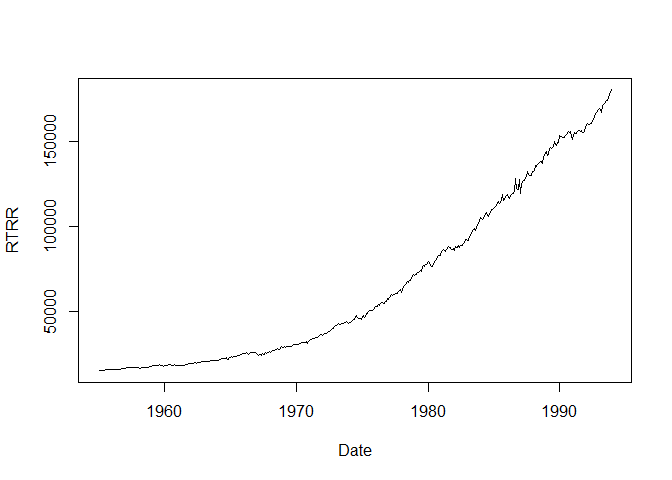

```r
# Figure 5.14
plot(RTRR~Date,type="l")
```

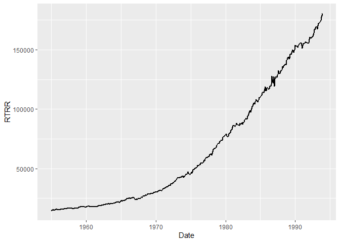

```r
ggplot(mydata,aes(Date,RTRR))+geom_line(size=1)
```

Хугацааны цувааг Зураг 5.14-д харуулав. График зурахтай холбоотой нэмэлт функцийг `?par()` командаар харах боломжтой юм. Энэхүү хэсэгт энгийн `plot()` болон илүү хүчирхэг `ggplot` багцын `ggplot()` функцийг ажиллуулсан болно. `ggplot` багц нь `tidyverse` багцад агуулагддаг тул дахин ачаалах шаардлагагүй юм. Анхан шатны агуулгатай (мэргэжлийн бус, сонирхогчийн) нийтлэлийн хувьд график, дүрслэлийн бурхан тэнгэр болсон `ggplot` багцыг тусад нь хичээл болгон оруулах тул уншигч танаас хүлцэл өчиж байна.

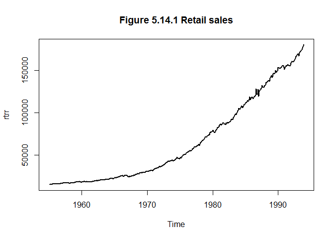

```r
# Figure 5.14
plot(rtrr,type="l",main="Figure 5.14.1 Retail sales",lwd=2)
```

## 2. Шугаман хэлбэртэй хандлага:

Энгийн регресс үнэлж буйтай яг ижилхэн зарчмаар хандлагыг загварчилж болно.

```r
# Table 5.1 Retail sales, linear trend regression
TIME<-1:length(rtrr)
reg1<-lm(rtrr~TIME)
result1<-summary(reg1)
result1
```

```
##
## Call:
## lm(formula = rtrr ~ TIME)
##
## Residuals:
##    Min     1Q Median     3Q    Max
## -22718 -13982  -2026  15151  33213
##
## Coefficients:
##               Estimate Std. Error t value Pr(>|t|)
## (Intercept) -16391.248   1469.177  -11.16   <2e-16 ***
## TIME           349.773      5.429   64.43   <2e-16 ***
## ---
## Signif. codes:  0 '***' 0.001 '**' 0.01 '*' 0.05 '.' 0.1 ' ' 1
##
## Residual standard error: 15870 on 466 degrees of freedom
## Multiple R-squared:  0.8991, Adjusted R-squared:  0.8989
## F-statistic:  4151 on 1 and 466 DF,  p-value: < 2.2e-16
```

```r
kable(xtable(reg1),caption = "**Table 5.1** Retail sales, linear trend regression")
```

**Table 5.1** Retail sales, linear trend regression

|  | Estimate | Std. Error | t value | Pr(>\|t\|) |
| --- | --- | --- | --- | --- |
| (Intercept) | -16391.2480 | 1469.17668 | -11.15676 | 0 |
| TIME | 349.7731 | 5.42867 | 64.43073 | 0 |

*Eviews* ийн үр дүнг *R* дээр гарган авах 2 боломжит арга байна.

Нэгдүгээр арга нь *dataframe* хэлбэрээр үзүүлэлтүүдийг оноож оруулах юм. Нэг талаар *R* дээр хийсэн байгаа тооцоолол, үр дүнгүүдийг *Eviews* хэлбэрээр авах л логик үйлчилж байгаа юм.

```r
# First method to take a Eviews result : to use data.frame
"Rsquared"=signif(result1$r.squared,digits = 6)
"Adjusted Rsquared"=signif(result1$adj.r.squared,digits = 6)
"SE"=round(result1$sigma,digits = 6)
"SSR"=ifelse(deviance(reg1)>1000000,round(deviance(reg1),
                                          digits = -8),round(deviance(reg1),digits = 6))
"Log lokelihood"=logLik(reg1)
"Durbin-Watson stat."=round(as.numeric(dwtest(reg1))[1],digits = 6)
"Mean dependent var."=mean(rtrr)
"SD dependent var."=sd(rtrr)
"Akaike info criterion"=AIC(reg1)
"Schwarz criterion"=BIC(reg1)
"F-statistic"=result1$r.squared/(1-result1$r.squared)*
  (length(RTRR)-(length(reg1$coefficients))/(length(reg1$coefficients)-1))
"p-value"=round(pf(result1$r.squared/(1-result1$r.squared)*
                     (length(RTRR)-(length(reg1$coefficients))/(length(reg1$coefficients)-1)),
                   length(reg1$coefficients)-1,length(RTRR)-(length(reg1$coefficients)),
                   lower.tail = F),digits = 6)
criteria<-c("Rsquared","Adjusted Rsquared","SE","SSR","Log lokelihood","Durbin-Watson stat.",
            "Mean dependent var.","SD dependent var.","Akaike info criterion","Schwarz criterion",
            "F-statistic","p-value")
Table5.1<-data.frame(Rsquared,`Adjusted Rsquared`,SE,SSR,`Log lokelihood`,
                     `Durbin-Watson stat.`,`Mean dependent var.`,`SD dependent var.`,
                     `Akaike info criterion`,`Schwarz criterion`,`F-statistic`,`p-value`)
print(Table5.1)
```

```
##   Rsquared Adjusted.Rsquared       SE       SSR Log.lokelihood
## 1 0.899076          0.898859 15866.12 1.173e+11      -5189.529
##   Durbin.Watson.stat. Mean.dependent.var. SD.dependent.var.
## 1            0.004682            65630.56          49889.26
##   Akaike.info.criterion Schwarz.criterion F.statistic p.value
## 1              10385.06           10397.5    4151.319       0
```

Дээрх аргыг ашиглах буюу утга бүрээр нь оноон өгөх нь нэг бодлын ярвигтай юм. Олон удаа регресс үнэлэх энэ загваруудад бол үлгэр шиг л санагдана. Иймд хүсэж буй үр дүнг нэгхэн мөр код бичээд авах боломж нь өөрийн функцийг зохиох явдал юм. Би хувьдаа өөрийн ядмаг мэдлэгийг ашиглан `ger()` функцийг бичлээ.

```r
# Second method to take Eviews result : Create own function
# GER - Get Eviews Result
ger<-function(regression,result,dependent.var){
  print(data.frame(value=c(result$r.squared
                           ,result$adj.r.squared
                           ,result$sigma,deviance(regression)
                           ,logLik(regression)
                           ,sum(diff(regression$residuals,lag=1)^2)/sum(regression$residuals^2)
                           ,mean(dependent.var),sd(dependent.var),AIC(regression),BIC(regression)
                           ,result$r.squared/(1-result$r.squared)
                           *(length(dependent.var)-(length(regression$coefficients))/(length(regression$coefficients)-1))
                           ,pf(result$r.squared/(1-result$r.squared)
                               *(length(dependent.var)-(length(regression$coefficients))/(length(regression$coefficients)-1))
                               ,length(regression$coefficients)-1,length(dependent.var)-(length(regression$coefficients))
                               ,lower.tail = F))
                   ,row.names = c("Rsquared","Adjusted Rsquared","SE","SSR","Log lokelihood",
                                  "Durbin-Watson stat.","Mean dependent var.","SD dependent var.",
                                  "Akaike info criterion","Schwarz criterion","F-statistic","p-value")))}
Table5.1.2<-ger(reg1,result1,rtrr)
```

```
##                                value
## Rsquared                8.990756e-01
## Adjusted Rsquared       8.988590e-01
## SE                      1.586612e+04
## SSR                     1.173079e+11
## Log lokelihood         -5.189529e+03
## Durbin-Watson stat.     4.681602e-03
## Mean dependent var.     6.563056e+04
## SD dependent var.       4.988926e+04
## Akaike info criterion   1.038506e+04
## Schwarz criterion       1.039750e+04
## F-statistic             4.151319e+03
## p-value                3.323512e-234
```

Энэхүү функц нь *Get Eviews Result* буюу *Eviews*-ийн үр дүнг авах гэсэн утгатай функц юм. Хар ухаандаа өмнөх оноож өгдөг аргыг функц болгож хувиргасан бөгөөд нэг дутагдалтай тал нь үр дүн “e” тэй гарч ирээд байгаа буюу ойролцоолох `round()` болон бусад оператор ажиллахгүй байгаа явдал юм. Харин үзүүлэлтийг нэг бүрээр нь дуудахад энэ асуудал үүсэхгүй байгаа нь авууштай.

```r
Table5.1.2$value[4]
```

```
## [1] 117307861336
```

```r
Table5.1.2$value[2]
```

```
## [1] 0.898859
```

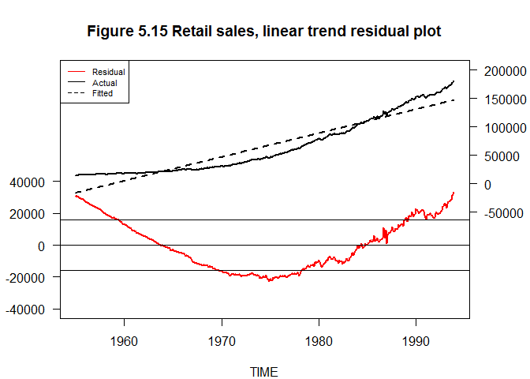

```r
# Figure 5.15 Retail sales, linear trend residual plot

par(mar=c(4,4,4,4))
plot(Date,RTRR,type="l",lwd=2
     ,main="Figure 5.15 Retail sales, linear trend residual plot"
     ,ylab="",yaxt="n",ylim=c(-220000,200000),bty="o",xlab="TIME")
par(new=T)
plot(Date,reg1$fitted.values,lwd=2,type="l",lty=2,ylab="",yaxt="n"
     ,ylim=c(-220000,200000),xaxt="n",xlab="")
axis(4,at=c(seq(-50000,200000,50000))
     ,labels = c("-50000","0","50000","100000","150000","200000")
     ,las=2,cex.axis=1,xlab="")
par(new=T)
plot(Date,reg1$residuals
     ,col="red",lwd=2,type="l",ylab="",yaxt="n"
     ,ylim=c(-40000,110000),xaxt="n",xlab="")
axis(2,at=c(seq(-40000,40000,20000))
     ,labels = c("-40000","-20000","0","20000","40000")
     ,las=2,cex.axis=1)
abline(h=mean(reg1$residuals))
abline(h=mean(reg1$residuals)+result1$sigma)
abline(h=mean(reg1$residuals)-result1$sigma)

legend("topleft",c("Residual","Actual","Fitted")
       ,lty=c(1,1,2),col=c("red","black","black"),cex=0.7)
```

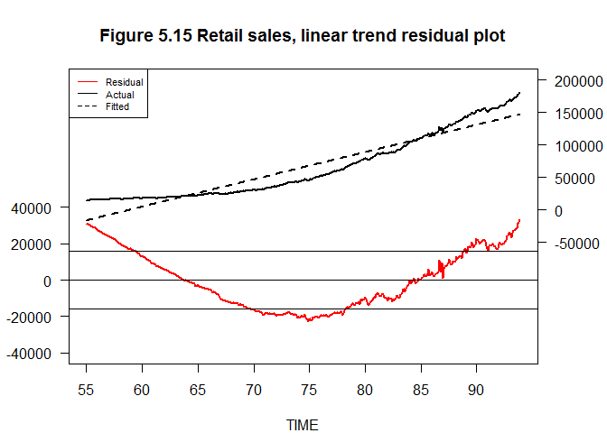

```r
# X axis simulation
par(mar=c(4,4,4,4))
plot.ts(rtrr,type="l",lwd=2
        ,main="Figure 5.15 Retail sales, linear trend residual plot"
        ,ylab="",yaxt="n",xaxt="n",ylim=c(-220000,200000),bty="o",xlab="TIME")
lines(ts(reg1$fitted.values,start = c(1955,1),end = c(1993,12),frequency = 12)
      ,lwd=2,lty=2,col="black")
axis(1,at=c(seq(1955,1990,5)),labels =c(seq(55,90,5)))
axis(4,at=c(seq(-50000,200000,50000))
     ,labels = c("-50000","0","50000","100000","150000","200000")
     ,las=2,cex.axis=1,xlab="")
par(new=T)
resid1<-ts(reg1$residuals,start = c(1955,1),end = c(1993,12),frequency = 12)
plot(resid1,col="red",lwd=2,type="l",ylab="",yaxt="n"
     ,ylim=c(-40000,110000),xaxt="n",xlab="")
axis(2,at=c(seq(-40000,40000,20000))
     ,labels = c("-40000","-20000","0","20000","40000")
     ,las=2,cex.axis=1)
abline(h=mean(resid1))
abline(h=mean(resid1)+result1$sigma)
abline(h=mean(resid1)-result1$sigma)

legend("topleft",c("Residual","Actual","Fitted")
       ,lty=c(1,1,2),col=c("red","black","black"),cex=0.7)
```

Энэ мэтчилэн квадратлаг болон хагас логарифм хэлбэрийг загварчилна.

## 3. Квадрат хэлбэртэй хандлага

```r
# Table 5.2 Retail sales, quadratic trend regression

TIME2<-TIME^2
reg2<-lm(rtrr~TIME+I(TIME^2))

reg2<-lm(rtrr~TIME+TIME2)
result2<-summary(reg2)

print(result2$coefficients)
```

```
##                  Estimate   Std. Error   t value      Pr(>|t|)
## (Intercept) 18708.7003219 3.799566e+02  49.23905 1.406007e-186
## TIME          -98.3112971 3.741388e+00 -26.27669  5.902748e-94
## TIME2           0.9554039 7.725091e-03 123.67544  0.000000e+00
```

```r
Table5.2<-ger(reg2,result2,rtrr) # this function use with lmtest function.
```

```
##                               value
## Rsquared               9.970223e-01
## Adjusted Rsquared      9.970095e-01
## SE                     2.728205e+03
## SSR                    3.461043e+09
## Log lokelihood        -4.365093e+03
## Durbin-Watson stat.    1.510894e-01
## Mean dependent var.    6.563056e+04
## SD dependent var.      4.988926e+04
## Akaike info criterion  8.738186e+03
## Schwarz criterion      8.754780e+03
## F-statistic            1.561999e+05
## p-value                0.000000e+00
```

**Table 5.2** Retail sales, quadratic trend regression

|  | Estimate | Std. Error | t value | Pr(>\|t\|) |
| --- | --- | --- | --- | --- |
| (Intercept) | 18708.7003 | 379.956551 | 49.2391 | 0 |
| TIME | -98.3113 | 3.741388 | -26.2767 | 0 |
| TIME2 | 0.9554 | 0.007725 | 123.6754 | 0 |

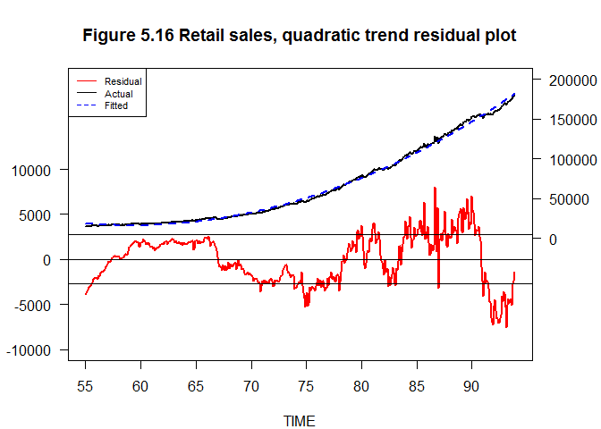

```r
# Figure 5.16 Retail sales, quadratic trend residual plot
par(mar=c(4,4,4,4))
plot(rtrr,type="l",lwd=2
     ,main="Figure 5.16 Retail sales, quadratic trend residual plot"
     ,ylab="",yaxt="n",xaxt="n",ylim=c(-140000,200000),bty="o",xlab="TIME")
lines(ts(reg2$fitted.values,start = c(1955,1),end = c(1993,12),frequency = 12)
      ,lwd=2,col="blue",lty=2)
axis(1,at=c(seq(1955,1990,5)),labels = c(seq(55,90,5)))
axis(4,at=c(seq(0,200000,50000))
     ,labels = c("0","50000","100000","150000","200000")
     ,las=2,cex.axis=1,xlab="")
#  curve(ts(reg2$residuals,start = c(1955,1),end = c(1993,12)
# ,frequency = 12),col="red",lwd=2,type="l",ylab="",yaxt="n"
# ,ylim=c(-10000,20000),xaxt="n",xlab="")
resid2<-ts(reg2$residuals,start = c(1955,1),end = c(1993,12),frequency = 12)
par(new=T)
plot(resid2,col="red",lwd=2,type="l",ylab="",yaxt="n"
     ,ylim=c(-10000,20000),xaxt="n",xlab="")
axis(2,at=c(seq(-10000,10000,5000))
     ,labels = c("-10000","-5000","0","5000","10000")
     ,las=2,cex.axis=1)
abline(h=mean(resid2))
abline(h=mean(resid2)+result2$sigma)
abline(h=mean(resid2)-result2$sigma)

legend("topleft",c("Residual","Actual","Fitted")
       ,lty=c(1,1,2),col=c("red","black","blue"),cex=0.7)
```

## 4. Хагас логарифм хэлбэртэй хандлага

```r
# Table 5.3 Retail sales, log-linear trend regression

reg3<-lm(log(rtrr)~TIME)
result3<-summary(reg3)

print(result3$coefficients)
```

```
##                Estimate   Std. Error   t value Pr(>|t|)
## (Intercept) 9.389974655 8.507844e-03 1103.6843        0
## TIME        0.005930689 3.143684e-05  188.6541        0
```

```r
Table5.3<-ger(reg3,result3,log(rtrr))
```

```
##                               value
## Rsquared               9.870758e-01
## Adjusted Rsquared      9.870481e-01
## SE                     9.187897e-02
## SSR                    3.933853e+00
## Log lokelihood         4.541874e+02
## Durbin-Watson stat.    1.994893e-02
## Mean dependent var.    1.078072e+01
## SD dependent var.      8.073254e-01
## Akaike info criterion -9.023748e+02
## Schwarz criterion     -8.899294e+02
## F-statistic            3.559036e+04
## p-value                0.000000e+00
```

**Table 5.3** Retail sales, log-linear trend regression

|  | Estimate | Std. Error | t value | Pr(>\|t\|) |
| --- | --- | --- | --- | --- |
| (Intercept) | 9.38997 | 0.008508 | 1103.6843 | 0 |
| TIME | 0.00593 | 0.000031 | 188.6541 | 0 |

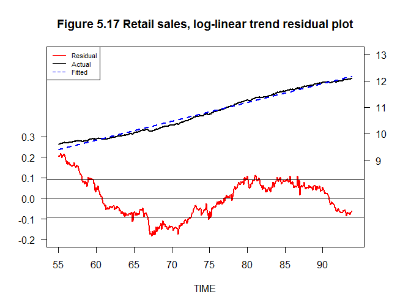

```r
par(mar=c(4,4,4,4))
plot(log(rtrr),type="l",lwd=2
     ,main="Figure 5.17 Retail sales, log-linear trend residual plot"
     ,ylab="",yaxt="n",xaxt="n",ylim=c(6,13),bty="o",xlab="TIME")
lines(ts(reg3$fitted.values,start = c(1955,1),end = c(1993,12),frequency = 12),lwd=2,lty=2,col="blue")
axis(1,at=c(seq(1955,1990,5)),labels = c(seq(55,90,5)))
axis(4,at=c(seq(9,13,1))
     ,labels = c("9","10","11","12","13"),las=2,cex.axis=1,xlab="")
resid3<-ts(reg3$residuals,start = c(1955,1),end = c(1993,12),frequency = 12)
par(new=T)
plot(resid3,col="red",lwd=2,type="l",ylab=""
     ,yaxt="n",ylim=c(-.2,.7),xaxt="n",xlab="")
axis(2,at=c(seq(-.2,.3,.1))
     ,labels = c("-0.2","-0.1","0.0","0.1","0.2","0.3")
     ,las=2,cex.axis=1)
abline(h=mean(resid3))
abline(h=mean(resid3)+result3$sigma)
abline(h=mean(resid3)-result3$sigma)

legend("topleft",c("Residual","Actual","Fitted")
       ,lty=c(1,1,2),col=c("red","black","blue"),cex=.7)
```

```r
# table 5.4 Retail sales, exponential trend regression
```

## 5. Экспоненциал хэлбэртэй хандлага

Экспоненциал гэж нэрлэгдсэн ч энэхүү *Eviews* дээр үнэлсэн тэгшитгэл нь *R* дээрх жирийн `exp()` функц ашигласнаас ондоо юм. Өөрөөр тогтмол нь экспоненциал хэлбэртэй биш байгаа тул `nls`*(nonlinear least squares)* функцийн тусламжтай параметрүүдийг урьдчилсан олох замаар энэхүү загварыг үнэллээ.

Диболд номын хэсгээс:

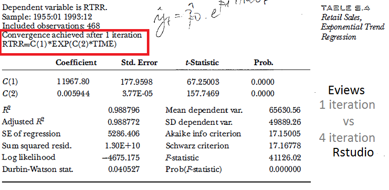

```r
parameters<-lm(log(rtrr)~TIME)
res<-summary(parameters)

reg4<-nls(rtrr~a*exp(b*TIME)
          ,start =c(a=exp(res$coefficients[1]),b=res$coefficients[2])
          ,trace=T)
```

```
## 13106462277 :  1.196780e+04 5.930689e-03
## 12465550980 :  1.279680e+04 5.771636e-03
## 12447822456 :  1.276582e+04 5.783612e-03
## 12447812932 :  1.276926e+04 5.782911e-03
## 12447812901 :  1.276907e+04 5.782951e-03
```

```r
reg4
```

```
## Nonlinear regression model
##   model: rtrr ~ a * exp(b * TIME)
##    data: parent.frame()
##         a         b
## 1.277e+04 5.783e-03
##  residual sum-of-squares: 1.245e+10
##
## Number of iterations to convergence: 4
## Achieved convergence tolerance: 2.941e-06
```

Үр дүн бага зэрэг зөрж буй нь *Eviews* ийн итерац нь 1 харин *R* хамгийн сайн тайлбарлах чадвартай загварыг сонгосон буюу 4 итерацын дараах загварыг сонгон авсан юм." (Өгөгдлийн шинжээч *М.Чойсүрэн* ахын тусламжтайгаар үүнийг олж харсан тул ишлэв. [Фэйсбүүк](https://www.facebook.com/choisuren.choi.1) болон [Rpubs](http://rpubs.com/Choisuren) цахим хаягийг орууллаа.)

```r
result4<-summary(reg4)

print(result4$coefficients)
```

```
##       Estimate   Std. Error   t value     Pr(>|t|)
## a 1.276907e+04 1.807096e+02  70.66072 3.75442e-251
## b 5.782951e-03 3.605723e-05 160.38255  0.00000e+00
```

```r
result4
```

```
##
## Formula: rtrr ~ a * exp(b * TIME)
##
## Parameters:
##    Estimate Std. Error t value Pr(>|t|)
## a 1.277e+04  1.807e+02   70.66   <2e-16 ***
## b 5.783e-03  3.606e-05  160.38   <2e-16 ***
## ---
## Signif. codes:  0 '***' 0.001 '**' 0.01 '*' 0.05 '.' 0.1 ' ' 1
##
## Residual standard error: 5168 on 466 degrees of freedom
##
## Number of iterations to convergence: 4
## Achieved convergence tolerance: 2.941e-06
```

```r
gernls<-function(regression,result,dependent.var,resid,parnum){
  print(data.frame(
    value=c(1-deviance(regression)/(sum((dependent.var-mean(dependent.var))^2))
            ,1-(deviance(regression)/(sum((dependent.var-mean(dependent.var))^2)))*((length(dependent.var)-1)/(length(dependent.var)-parnum-1))
            ,result$sigma,deviance(regression)
            ,logLik(regression)
            ,sum(diff(resid,lag = 1)^2)/sum(resid^2),mean(dependent.var)
            ,sd(dependent.var)
            ,AIC(regression)
            ,BIC(regression)
            ,as.numeric((1-deviance(regression)/(sum((dependent.var-mean(dependent.var))^2)))
                        /(deviance(regression)/(sum((dependent.var-mean(dependent.var))^2)))
                        *((length(dependent.var)-parnum)/(parnum-1)))
            ,pf((1-deviance(regression)/(sum((dependent.var-mean(dependent.var))^2)))
                /(deviance(regression)/(sum((dependent.var-mean(dependent.var))^2)))
                *((length(dependent.var)-parnum)/(parnum-1))
                ,parnum-1,length(dependent.var)-parnum,lower.tail = F))
    ,row.names = c("Rsquared","Adjusted Rsquared","SE","SSR","Log lokelihood","Durbin-Watson stat."
                   ,"Mean dependent var.","SD dependent var.","Akaike info criterion"
                   ,"Schwarz criterion","F-statistic","p-value")))}
Table5.4<-gernls(reg4,result4,rtrr,result4$residuals,2)
```

```
##                               value
## Rsquared               9.892907e-01
## Adjusted Rsquared      9.892446e-01
## SE                     5.168370e+03
## SSR                    1.244781e+10
## Log lokelihood        -4.664607e+03
## Durbin-Watson stat.    4.231971e-02
## Mean dependent var.    6.563056e+04
## SD dependent var.      4.988926e+04
## Akaike info criterion  9.335215e+03
## Schwarz criterion      9.347660e+03
## F-statistic            4.304749e+04
## p-value                0.000000e+00
```

**Table 5.4** Retail sales, exponential trend regression

|  | value |
| --- | --- |
| Rsquared | 9.892900e-01 |
| Adjusted Rsquared | 9.892400e-01 |
| SE | 5.168370e+03 |
| SSR | 1.244781e+10 |
| Log lokelihood | -4.664607e+03 |
| Durbin-Watson stat. | 4.232000e-02 |
| Mean dependent var. | 6.563056e+04 |
| SD dependent var. | 4.988926e+04 |
| Akaike info criterion | 9.335215e+03 |
| Schwarz criterion | 9.347660e+03 |
| F-statistic | 4.304749e+04 |
| p-value | 0.000000e+00 |

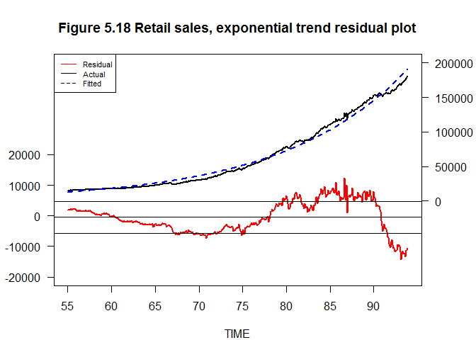

```r
# Figure 5.18 Retail sales, Exponential trend residual plot

par(mar=c(4,4,4,4))
plot(rtrr,type="l",lwd=2
     ,main="Figure 5.18 Retail sales, exponential trend residual plot"
     ,ylab="",yaxt="n",xaxt="n",ylim=c(-110000,200000),bty="o",xlab="TIME")
lines(ts(predict(reg4,list(Date)),start = c(1955,1),end = c(1993,12),frequency = 12)
      ,col="blue",lty=2,lwd=2)
axis(1,at=c(seq(1955,1990,5)),labels = c(seq(55,90,5)))
axis(4,at=c(seq(0,200000,50000))
     ,labels = c("0","50000","100000","150000","200000")
     ,las=2,cex.axis=1,xlab="")
resid4<-rtrr-predict(reg4)
par(new=T)
plot(resid4,col="red",lwd=2,type="l",ylab="",yaxt="n"
     ,ylim=c(-20000,50000),xaxt="n",xlab="")

axis(2,at=c(seq(-20000,20000,10000))
     ,labels = c("-20000","-10000","0","10000","20000")
     ,las=2,cex.axis=1)
abline(h=mean(resid4))
abline(h=mean(resid4)+result4$sigma)
abline(h=mean(resid4)-result4$sigma)

legend("topleft",c("Residual","Actual","Fitted")
       ,lty=c(1,1,2),col=c("red","black","black"),cex=.7)
```

## 6. Хамгийн сайн загвар

Онолын дагуу хамгийн бага AIC,SIC тай загварыг сонгон авдаг. 2 программын тооцоолол ондоо учир харилцан адилгүй гардаг боловч үндсэн зорилгыг биелүүлдэг юм.

Мэдээллийн шинжүүрүүд, тооцоолол:

[figure not shown]

```r
# Table 5.5 Model selection criteria linear,quadratic and exponential trend models
linear_trend<-c(AIC(reg1),BIC(reg1))
quadratic_trend<-c(AIC(reg2),BIC(reg2))
exponential_trend<-c(AIC(reg4),BIC(reg4))
Table5.5<-data.frame(linear_trend,quadratic_trend,exponential_trend
                     ,row.names = c("AIC","SIC"))
print(Table5.5)
```

```
##     linear_trend quadratic_trend exponential_trend
## AIC     10385.06        8738.186          9335.215
## SIC     10397.50        8754.780          9347.660
```

**Table 5.5** Model selection criteria linear,quadratic and exponential trend models

|  | linear_trend | quadratic_trend | exponential_trend |
| --- | --- | --- | --- |
| AIC | 10385.06 | 8738.186 | 9335.215 |
| SIC | 10397.50 | 8754.780 | 9347.660 |

## 7. Таамаглал болон бодит байдал

Энэ хэсэгт сонгосон загвараар таамаглал хийлээ. *Eviews* ийн үр дүнг буюу графикийг *R* дээр гаргаж авах зорилгыг агуулж байгаа тул механик үйлдэл их хийсэн бөгөөд үүндээ хүлцэл өчиж байна. *R* дээр таамаглал хийхэд арай өөр дүрслэл харагддаг билээ.

```r
History<-ts(data[1081:1128,4],start = c(1990,1),end = c(1993,12),frequency = 12)
Realization<-ts(data[1081:1140,4],start = c(1990,1),end =c(1994,12),frequency = 12)
```

*R* дээрх таамаглал хийж буй хэв маяг:

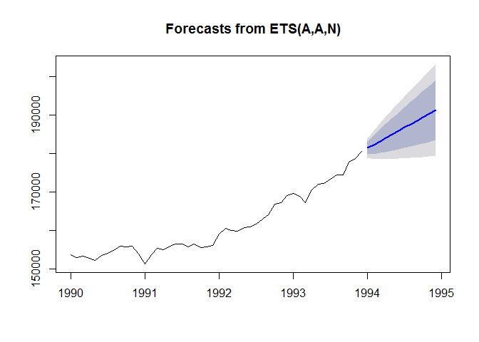

```r
plot(forecast(History,h=12))  # We can customize our plot.
```

*Eviews* - ийн үр дүнг гаргаж авав.

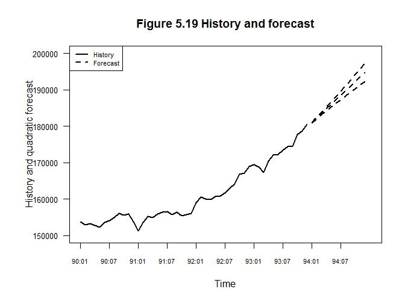

```r
# Figure 5.19 Retail sales: History 1990.01-1993.12 and quadratic trend forecast 1994.01-1994.12
t<-1:length(History)
t2<-t^2
q<-lm(History~t+t2)
ts.q<-ts(q$fitted.values,start = c(1990,01),end = c(1993,12),frequency = 12)
qforecast<-forecast(ts.q,h=12,level=.95)
par(mar=c(4,6,4,2))
plot(History,ylim = c(150000,200000),lwd=2,type="l",xlim=c(1990.01,1995.01)
     ,yaxt="n",xaxt="n"
     ,ylab="History and quadratic forecast"
     ,main="Figure 5.19 History and forecast")
axis(1,at=c(seq(1990,1994.7,.5)),
     labels = c("90:01","90:07","91:01","91:07","92:01","92:07","93:01","93:07","94:01","94:07")
     ,cex.axis=.7)
axis(2,at=c(seq(150000,200000,10000)),
     labels=c("150000","160000","170000","180000","190000","200000"),
     las=2,cex.axis=.8)
lines(qforecast$mean,lty=2,lwd=2)
lines(qforecast$upper,lty=2,lwd=2)
lines(qforecast$lower,lty=2,lwd=2)
legend("topleft",c("History","Forecast"),lty=c(1,2),
       lwd=2,col=c("black","black"),cex=.7)
```

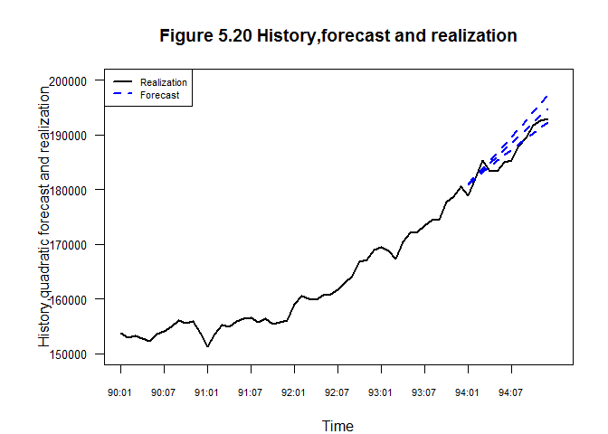

```r
# Figure 5.20 Retail sales: History 1990.01-1993.12 and quadratic trend forecast and realization 1994.01-1994.12
plot(Realization,type="l",lwd=2,ylim = c(150000,200000),xlim=c(1990.01,1995.01),yaxt="n",xaxt="n",
     ylab="History,quadratic forecast and realization",
     main="Figure 5.20 History,forecast and realization")
axis(1,at=c(seq(1990,1994.7,.5)),
     labels = c("90:01","90:07","91:01","91:07","92:01","92:07",
                "93:01","93:07","94:01","94:07"),cex.axis=.7)
axis(2,at=c(seq(150000,200000,10000)),
     labels=c("150000","160000","170000","180000","190000",
              "200000"),las=2,cex.axis=.8)
lines(qforecast$mean,lty=2,lwd=2,col="blue")
lines(qforecast$upper,lty=2,lwd=2,col="blue")
lines(qforecast$lower,lty=2,lwd=2,col="blue")

legend("topleft",c("Realization","Forecast"),lty=c(1,2),
       lwd=2,col=c("black","blue"),cex=.7)
```

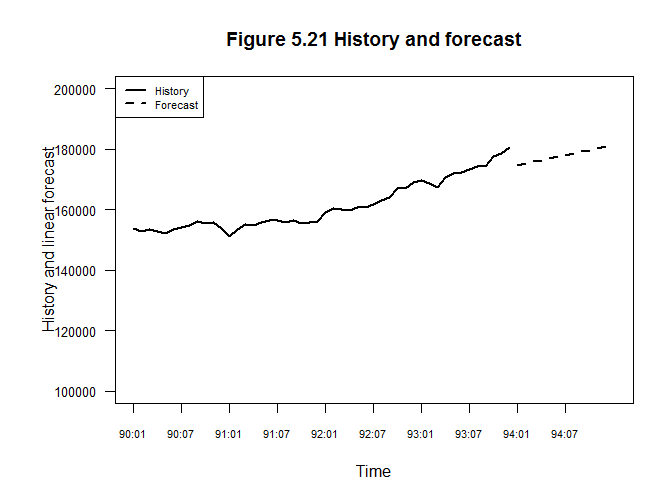

```r
# Figure 5.21 Retail sales: History 1990.01-1993.12; and linear trend forecast,1994.01-1994.12

l<-lm(History~t)
ts.l<-ts(l$fitted.values,start = c(1990,01),end = c(1993,12),frequency = 12)
lforecast<-forecast(ts.l,h=12,level = .95)

par(mar=c(4,6,4,2))
plot(History,ylim = c(100000,200000),type="l",lwd=2,xlim=c(1990.01,1995.01),yaxt="n",
     xaxt="n",ylab="History and linear forecast",
     main="Figure 5.21 History and forecast")
axis(1,at=c(seq(1990,1994.7,.5)),
     labels = c("90:01","90:07","91:01","91:07","92:01","92:07",
                "93:01","93:07","94:01","94:07"),cex.axis=.7)
axis(2,at=c(seq(100000,200000,20000)),
     labels=c("100000","120000","140000","160000","180000",
              "200000"),las=2,cex.axis=.8)
lines(lforecast$mean,lty=2,lwd=2)
lines(lforecast$upper,lty=2,lwd=2)
lines(lforecast$lower,lty=2,lwd=2)
legend("topleft",c("History","Forecast"),lty=c(1,2),lwd=2,col=c("black","black"),cex=.7)
```

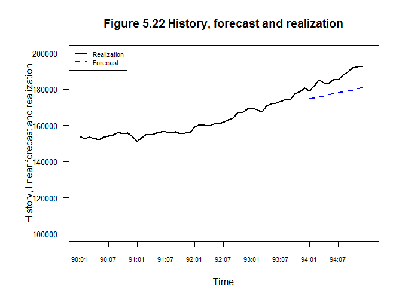

```r
library(forecast)

# Figure 5.22 Retail sales: History 1990.01-1993.12; and linear trend forecast and realization,1994.01-1994.12
par(mar=c(4,6,4,2))
plot(Realization,lty=c(1,2),lwd=2,ylim = c(100000,200000),type="l",xlim=c(1990.01,1995.01),
     ylab="History, linear forecast and realization",yaxt="n",xaxt="n",
     main="Figure 5.22 History, forecast and realization")
axis(1,at=c(seq(1990,1994.7,.5))
     ,labels = c("90:01","90:07","91:01","91:07","92:01","92:07","93:01","93:07","94:01","94:07")
     ,cex.axis=.7)
axis(2,at=c(seq(100000,200000,20000))
     ,labels=c("100000","120000","140000","160000","180000","200000")
     ,las=2,cex.axis=.8)
lines(lforecast$mean,lty=2,lwd=2,col="blue")
legend("topleft",c("Realization","Forecast")
       ,lty=c(1,2),lwd=2,col=c("black","blue"),cex=.7)
```

## 8.Ашигласан материал:

[Diebold https://www.sas.upenn.edu/~fdiebold/Textbooks.html](https://www.sas.upenn.edu/~fdiebold/Textbooks.html)

*Хичээлтэй холбоотой санал сэтгэгдлийг мэйл хаяг болон [фэйсбүүк](https://www.facebook.com/O.Lkhagwasuren) хаягаар нээлттэй хүлээн авах болно . Мөн коммент хэсэгт бичих боломжтой.*